# CASA 0005 GIS and Science Seminar 5

## An Introduction to Origin-Destination datasets

This seminar introduces the use of two packages for dealing with network datasets, **igraph** and **stplanr**. **igraph** is a really well known package of functions to manipulate graphs and analyse networks, and **stplanr** is a package created by Robin Lovelace to visualise and manipulate OD datasets with and emphasis on spatial transport data.

You can find more about the use of **stplanr** in https://geocompr.robinlovelace.net/transport.html

Learning outcomes of this seminar:

- Understand the structure of OD datasets
- Extract data from https://geoportal.statistics.gov.uk/
- Visualise commuting networks
- Introduce basic analyses

### 1 Getting started

```r
#install.packages(c("igraph","ggplot2","rgdal","rgeos","downloader","geosphere","tmap"))

library(igraph) # to create and analyse graphs
library(stplanr) # to
library(pct) # To
library(dplyr)
library(ggplot2)
library(sf)
library(tmap)
```

### 2 Load the data

What do we need to construct the network?

OD networks represent movement flows between locations. The flow is represented by an **edge** connecting origin and destination **nodes**. To construct the network we need data from both: edges and nodes. Flows dasets usually consist on starting and end point columns, and other columns with some non-geographical attributes i.e. flow count, methods, distance, time, gender. This will be used to construct the edges. For the nodes’ table we need an ID column (matching start and end point in main data), and a column with their geographic coordinates.

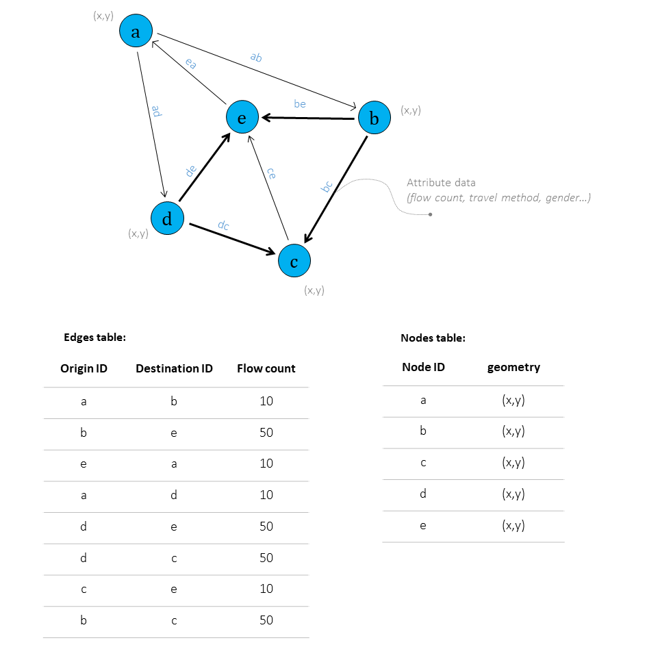

We will look at commuting flows in Manchester. To download the data we will use **pct** package, which allows us to extract datasets from https://geoportal.statistics.gov.uk/.But, you can download your own csv. data an read it in R.

```r
#Flows data

flows_data <-get_od(
  region = NULL,
  n = NULL,
  type = "within",
  omit_intrazonal = FALSE,
  base_url = paste0("https://s3-eu-west-1.amazonaws.com/",
                    "statistics.digitalresources.jisc.ac.uk", "/dkan/files/FLOW/"),
  filename = "wu03ew_v2"
)
```

```r
head(flows_data)
```

```
## # A tibble: 6 x 18
##   geo_code1 geo_code2   all from_home light_rail train   bus  taxi motorbike
##   <chr>     <chr>     <dbl>     <dbl>      <dbl> <dbl> <dbl> <dbl>     <dbl>
## 1 E02000001 E02000001  1506         0         73    41    32     9         1
## 2 E02000001 E02000014     2         0          2     0     0     0         0
## 3 E02000001 E02000016     3         0          1     0     2     0         0
## 4 E02000001 E02000025     1         0          0     1     0     0         0
## 5 E02000001 E02000028     1         0          0     0     0     0         0
## 6 E02000001 E02000051     1         0          1     0     0     0         0
## # ... with 9 more variables: car_driver <dbl>, car_passenger <dbl>,
## #   bicycle <dbl>, foot <dbl>, other <dbl>, geo_name1 <chr>, geo_name2 <chr>,
## #   la_1 <chr>, la_2 <chr>
```

```r
#Nodes data MSOA level
nodes_data <- pct::get_centroids_ew() %>% sf::st_transform(27700)
```

```r
head(nodes_data)
```

```
## Simple feature collection with 6 features and 2 fields
## geometry type:  POINT
## dimension:      XY
## bbox:           xmin: 445583 ymin: 515117 xmax: 461358 ymax: 525455
## projected CRS:  OSGB 1936 / British National Grid
## # A tibble: 6 x 3
##   msoa11cd  msoa11nm                        geometry
##   <chr>     <chr>                        <POINT [m]>
## 1 E02002536 Stockton-on-Tees 002     (445583 524174)
## 2 E02002537 Stockton-on-Tees 003     (446778 524256)
## 3 E02002534 Redcar and Cleveland 020 (461358 515117)
## 4 E02002535 Stockton-on-Tees 001     (446118 525455)
## 5 E02002532 Redcar and Cleveland 018 (461054 516174)
## 6 E02002533 Redcar and Cleveland 019 (460441 515185)
```

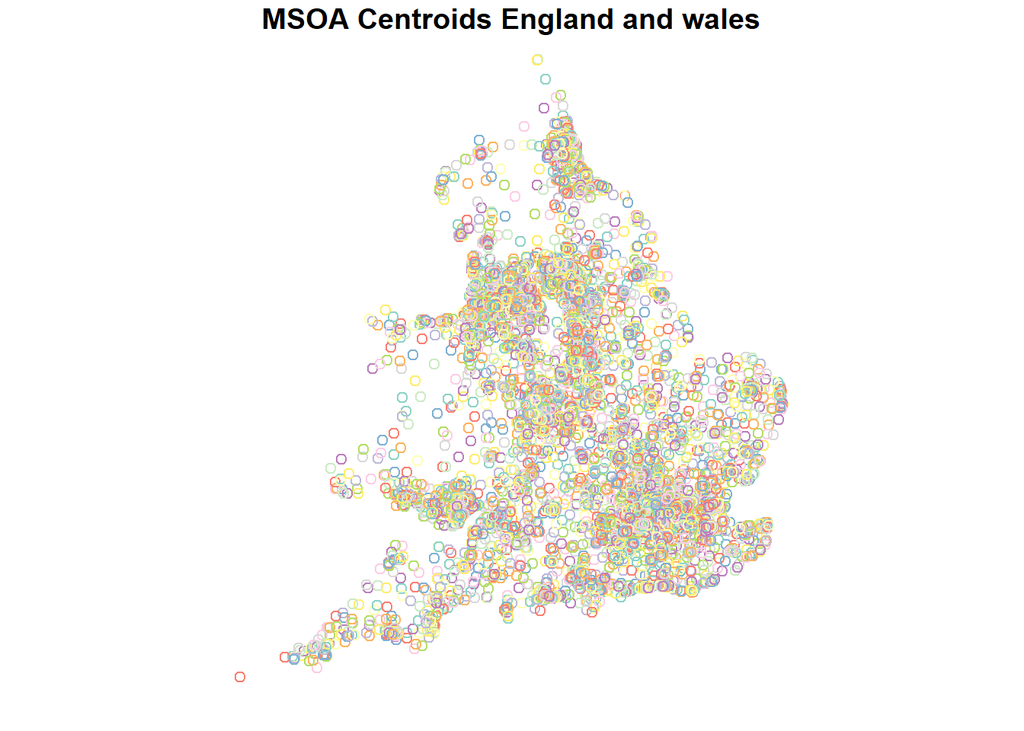

```r
plot(nodes_data["msoa11cd"], main="MSOA Centroids England and wales")
```

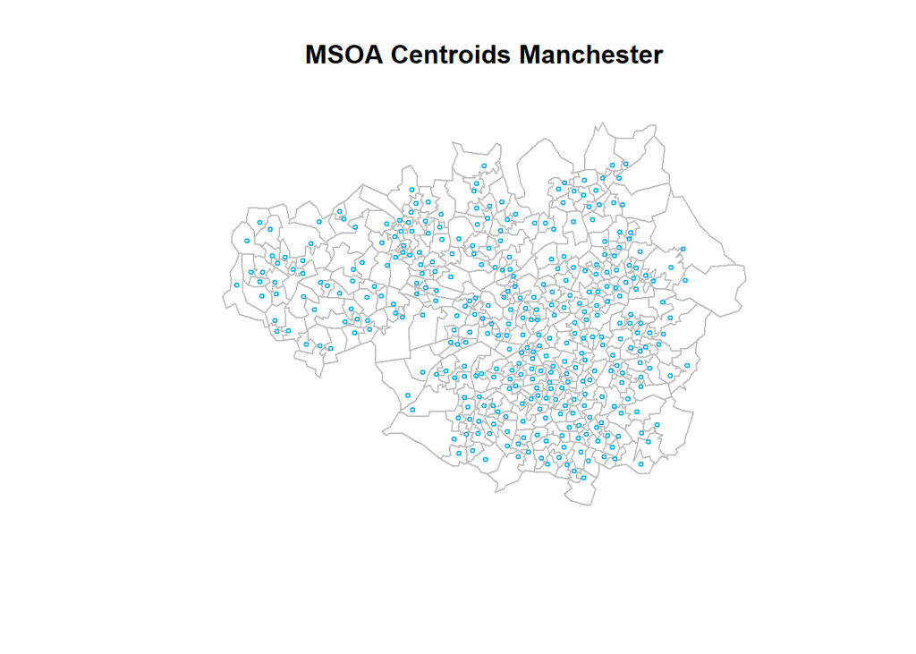

```r
#For Manchester

manchester_polygon <- pct::pct_regions %>% filter(region_name == "greater-manchester")%>%
  st_transform(.,27700)

 nodes_manchester <- nodes_data[manchester_polygon, ]

msoa_manchester <- pct::get_pct_zones("greater-manchester",geography="msoa") %>%
  select("geo_code")%>% sf::st_transform(27700)


plot(st_geometry(msoa_manchester),col="white", border="gray", main="MSOA Centroids Manchester")
plot(st_geometry(nodes_manchester), cex=0.5, col="deepskyblue2", add=TRUE)
```

```r
#For Manchester

flows_data_manchester <- flows_data %>%
  filter(geo_code1 %in% nodes_manchester$msoa11cd) %>%
  filter(geo_code2 %in% nodes_manchester$msoa11cd)
```

### 3 Construct the network

Here we will use **stplanr** package, but you can also use **igraph** to do it.

```r
#Create the network
commuting_network <- od2line(flows_data_manchester, nodes_manchester)
```

```r
head(commuting_network)
```

```
## Simple feature collection with 6 features and 18 fields
## geometry type:  LINESTRING
## dimension:      XY
## bbox:           xmin: 363866 ymin: 411498 xmax: 374421 ymax: 414031
## projected CRS:  OSGB 1936 / British National Grid
##   geo_code1 geo_code2 all from_home light_rail train bus taxi motorbike
## 1 E02000984 E02000984 184         0          0     9   0    0         0
## 2 E02000984 E02000985 106         0          0     1   2    1         0
## 3 E02000984 E02000986  68         0          0     0   0    1         0
## 4 E02000984 E02000987  27         0          0     0   0    0         0
## 5 E02000984 E02000988 122         0          0     0   2    0         0
## 6 E02000984 E02000989  25         0          0     0   1    0         0
##   car_driver car_passenger bicycle foot other  geo_name1  geo_name2   la_1
## 1        104             7       0   63     1 Bolton 001 Bolton 001 Bolton
## 2         69             9       1   23     0 Bolton 001 Bolton 002 Bolton
## 3         43             3       0   21     0 Bolton 001 Bolton 003 Bolton
## 4         25             1       0    1     0 Bolton 001 Bolton 004 Bolton
## 5         87            17       0   15     1 Bolton 001 Bolton 005 Bolton
## 6         24             0       0    0     0 Bolton 001 Bolton 006 Bolton
##     la_2                       geometry
## 1 Bolton LINESTRING (371394 414031, ...
## 2 Bolton LINESTRING (371394 414031, ...
## 3 Bolton LINESTRING (371394 414031, ...
## 4 Bolton LINESTRING (371394 414031, ...
## 5 Bolton LINESTRING (371394 414031, ...
## 6 Bolton LINESTRING (371394 414031, ...
```

[figure not shown]

```r
# Inter and Intra movement
inter_movement <- commuting_network %>% filter(geo_code1 != geo_code2)
intra_movement <- commuting_network %>% filter(geo_code1 == geo_code2)
```

```r
head(inter_movement)
```

```
## Simple feature collection with 6 features and 18 fields
## geometry type:  LINESTRING
## dimension:      XY
## bbox:           xmin: 363866 ymin: 410991 xmax: 374421 ymax: 414031
## projected CRS:  OSGB 1936 / British National Grid
##   geo_code1 geo_code2 all from_home light_rail train bus taxi motorbike
## 1 E02000984 E02000985 106         0          0     1   2    1         0
## 2 E02000984 E02000986  68         0          0     0   0    1         0
## 3 E02000984 E02000987  27         0          0     0   0    0         0
## 4 E02000984 E02000988 122         0          0     0   2    0         0
## 5 E02000984 E02000989  25         0          0     0   1    0         0
## 6 E02000984 E02000990  82         0          0     0   3    1         1
##   car_driver car_passenger bicycle foot other  geo_name1  geo_name2   la_1
## 1         69             9       1   23     0 Bolton 001 Bolton 002 Bolton
## 2         43             3       0   21     0 Bolton 001 Bolton 003 Bolton
## 3         25             1       0    1     0 Bolton 001 Bolton 004 Bolton
## 4         87            17       0   15     1 Bolton 001 Bolton 005 Bolton
## 5         24             0       0    0     0 Bolton 001 Bolton 006 Bolton
## 6         70             7       0    0     0 Bolton 001 Bolton 007 Bolton
##     la_2                       geometry
## 1 Bolton LINESTRING (371394 414031, ...
## 2 Bolton LINESTRING (371394 414031, ...
## 3 Bolton LINESTRING (371394 414031, ...
## 4 Bolton LINESTRING (371394 414031, ...
## 5 Bolton LINESTRING (371394 414031, ...
## 6 Bolton LINESTRING (371394 414031, ...
```

```r
head(intra_movement)
```

```
## Simple feature collection with 6 features and 18 fields
## geometry type:  LINESTRING
## dimension:      XY
## bbox:           xmin: 363866 ymin: 411498 xmax: 374421 ymax: 414031
## projected CRS:  OSGB 1936 / British National Grid
##   geo_code1 geo_code2 all from_home light_rail train bus taxi motorbike
## 1 E02000984 E02000984 184         0          0     9   0    0         0
## 2 E02000985 E02000985 211         0          0    11   6    1         1
## 3 E02000986 E02000986 149         0          0     1   4    0         0
## 4 E02000987 E02000987 320         0          0     3   9    1         0
## 5 E02000988 E02000988 314         0          0     6  15    3         1
## 6 E02000989 E02000989 146         0          1     4   3    1         0
##   car_driver car_passenger bicycle foot other  geo_name1  geo_name2   la_1
## 1        104             7       0   63     1 Bolton 001 Bolton 001 Bolton
## 2        111            13       0   68     0 Bolton 002 Bolton 002 Bolton
## 3         66             6       1   71     0 Bolton 003 Bolton 003 Bolton
## 4        121            13       7  166     0 Bolton 004 Bolton 004 Bolton
## 5        106            10       4  169     0 Bolton 005 Bolton 005 Bolton
## 6         86             9       0   42     0 Bolton 006 Bolton 006 Bolton
##     la_2                       geometry
## 1 Bolton LINESTRING (371394 414031, ...
## 2 Bolton LINESTRING (373096 412761, ...
## 3 Bolton LINESTRING (371765 412617, ...
## 4 Bolton LINESTRING (363866 411826, ...
## 5 Bolton LINESTRING (371306 411686, ...
## 6 Bolton LINESTRING (374421 411498, ...
```

### 4 Visualising the network

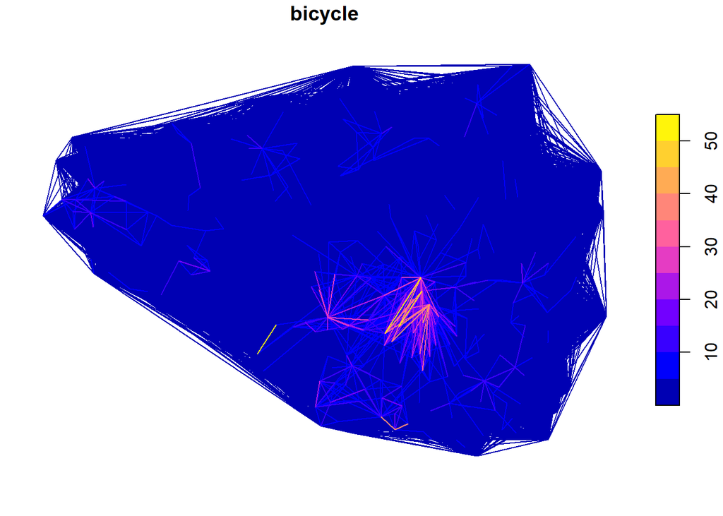

```r
# flows by bicycle
min_flows <- 1
inter_movement_bike  <- inter_movement  %>% filter(bicycle >= min_flows)
inter_movement_bike <- inter_movement %>% arrange(.,bicycle)



plot(inter_movement_bike["bicycle"])
```

```r
tmap_mode("view")

tm_shape(inter_movement_bike) +
  tm_lines(
    palette = "plasma", breaks = c(0, 5, 10, 20, 40, 60),
    lwd="bicycle",
    scale = 9,
    title.lwd = "Number of trips",
    alpha = 0.5,
    col = "bicycle",
    title = "Bicycle",
    lwd.legend = c(0.5, 1.5, 2.5, 3),
    legend.lwd.show = FALSE)
```

### 5 MSOA out-comming and in-comming flows

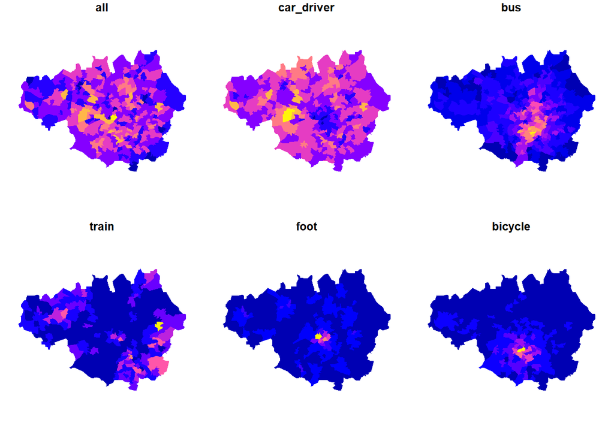

```r
out_flow_bymode <- inter_movement %>%
  sf::st_drop_geometry() %>%
  group_by(geo_code1) %>%
  summarize_if(is.numeric, sum) %>%
  dplyr::rename(geo_code = geo_code1)

msoa_outcomming <- left_join(msoa_manchester, out_flow_bymode , by = "geo_code")

plot(msoa_outcomming[c("all", "car_driver","bus", "train", "foot", "bicycle")], border = NA)
```

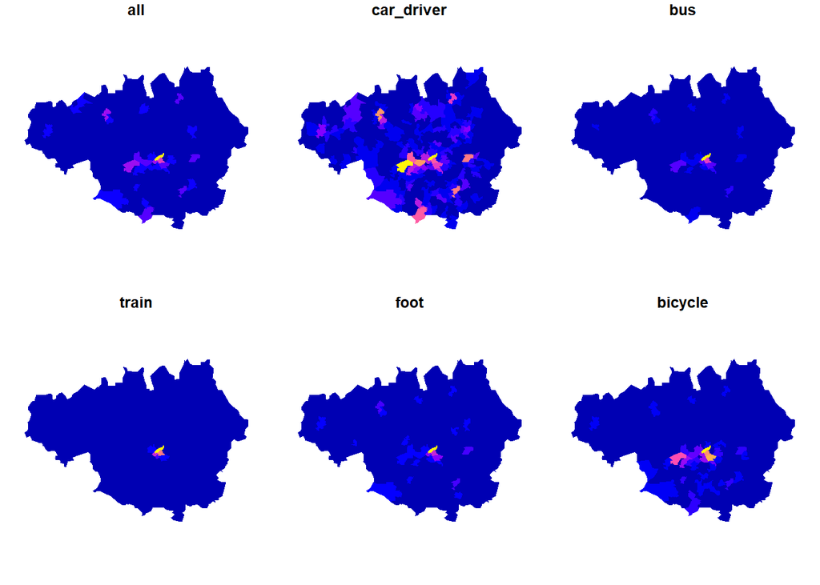

```r
in_flow_bymode <- inter_movement %>%
  sf::st_drop_geometry() %>%
  group_by(geo_code2) %>%
  summarize_if(is.numeric, sum) %>%
  dplyr::rename(geo_code = geo_code2)

msoa_incomming <- left_join(msoa_manchester, in_flow_bymode , by = "geo_code")

plot(msoa_incomming[c("all", "car_driver","bus", "train", "foot", "bicycle")], border = NA)
```

### 6 Degree distribution for out-comming and in-comming flows

```r
min_flows<-20

inter_movement_graph = inter_movement %>% select("geo_code1","geo_code2","all", "car_driver","bus", "train", "foot", "bicycle")%>% filter(all > min_flows)

G=graph.data.frame(inter_movement_graph,directed=T)
```

```r
head(get.edgelist(G))
```

```
##      [,1]        [,2]
## [1,] "E02000984" "E02000985"
## [2,] "E02000984" "E02000986"
## [3,] "E02000984" "E02000987"
## [4,] "E02000984" "E02000988"
## [5,] "E02000984" "E02000989"
## [6,] "E02000984" "E02000990"
```

```r
summary(components(G))
```

```
##            Length Class  Mode
## membership 346    -none- numeric
## csize        1    -none- numeric
## no           1    -none- numeric
```

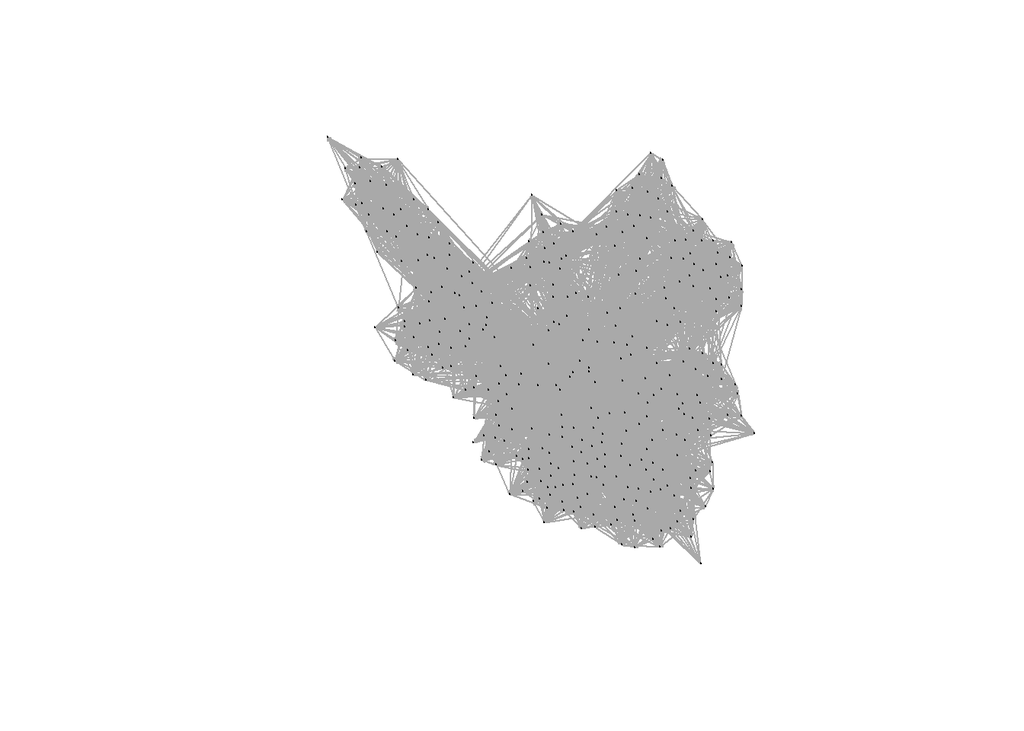

```r
plot(G, vertex.label=NA,vertex.size=.5,edge.arrow.size=0.1)
```

```r
seal_coords <- do.call(rbind, st_geometry(nodes_manchester$geometry)) %>%
  as_tibble() %>% setNames(c("lon","lat"))

nodes_manchester$x<-seal_coords$lon
nodes_manchester$y<-seal_coords$lat

coordsPoints=as.data.frame(nodes_manchester[nodes_manchester$msoa11cd %in% V(G)$name,],edge.curved=FALSE)
```

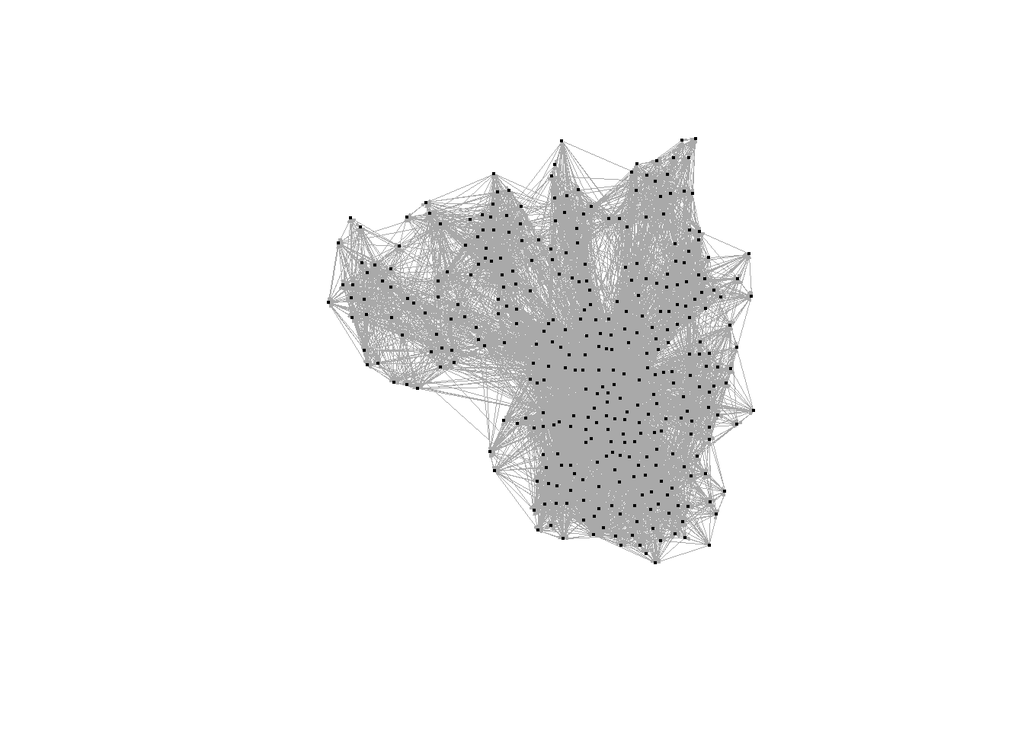

```r
matched=match(V(G)$name,coordsPoints[,1])
V(G)$x=coordsPoints[matched,4]
V(G)$y=coordsPoints[matched,5]

plot(G, vertex.label=NA,vertex.size=1.5, vertex.color = "deepskyblue2", vertex.frame.color = "black", edge.width=.1, edge.arrow.size=0.1,)
```

```r
V(G)$degree<-degree(G)
```

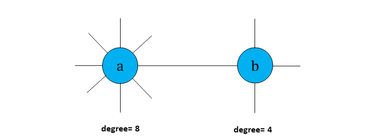

```r
head(V(G)$degree)
```

```
## [1] 38 43 34 27 55 34
```

```r
max(V(G)$degree)
```

```
## [1] 343
```

```r
min(V(G)$degree)
```

```
## [1] 14
```

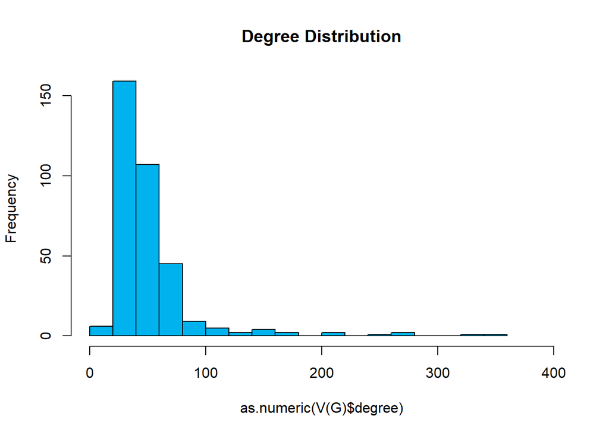

```r
hist(as.numeric(V(G)$degree), breaks=15,
     main="Degree Distribution",
     col="deepskyblue2",
     xlim=c(0,400))
```

### 7 Distance

```r
inter_movement$distance = as.numeric(st_length(inter_movement))
```